# **Male aDN>TNT courtship behaviour in the dark**

Aaron M. Allen

5th December 2020

# **Load packages**

Loading in the packages that we'll need for the analysis.

```r
library(tidyverse)
library(survminer)
library(survival)
library(data.table)
library(ggpubr)
library(zoo)
library(ggbeeswarm)
library(cowplot)
```

# **Load data**

This first bit is a lot of data import and manipulation to get it already to plot the courtship features.

First we'll load in the "key" tables with the genotypes, and do a little cleaning.

```r
genotypes_a <- read_csv(file = "aDN_A_male_dark.csv", col_names = c("video","fly_id","empty","copulation_frame")) %>% select(-empty) %>% mutate(genotype = "a")
genotypes_b <- read_csv(file = "aDN_B_male_dark.csv", col_names = c("video","fly_id","empty","copulation_frame")) %>% select(-empty) %>% mutate(genotype = "b")
genotypes_c <- read_csv(file = "aDN_C_male_dark.csv", col_names = c("video","fly_id","empty","copulation_frame")) %>% select(-empty) %>% mutate(genotype = "c")
genotypes_d <- read_csv(file = "aDN_D_male_dark.csv", col_names = c("video","fly_id","empty","copulation_frame")) %>% select(-empty) %>% mutate(genotype = "d")
genotypes <- bind_rows(genotypes_a,genotypes_b,genotypes_c,genotypes_d)
genotypes$video <- str_to_lower(genotypes$video)
genotypes$video <- str_trim(genotypes$video, side = "both")
head(genotypes)
```

| video | fly_id | copulation_frame | genotype |
| --- | --- | --- | --- |
| annika-2020_10_08_courtship-2020_10_08_adn_dark | 11 | 37490 | a |
| annika-2020_10_08_courtship-2020_10_08_adn_dark | 13 | 65318 | a |
| annika-2020_10_08_courtship-2020_10_08_adn_dark | 15 | 24670 | a |
| annika-2020_10_08_courtship-2020_10_08_adn_dark | 17 | None | a |
| annika-2020_10_08_courtship-2020_10_08_adn_dark | 20 | 2117 | a |
| annika-2020_10_09_courtship-2020_10_09_adn_dark | 11 | 15984 | a |

Next we're replacing the "None" values for the flies that didn't copulate within an hour with `NA`. We're also creating 2 new variables - `status` which is used for the cumulative copulation analysis, and `copulation_time` which is just converting the frame number into seconds.

```r
genotypes$copulation_frame[genotypes$copulation_frame=="None"] <- NA
genotypes <- genotypes %>%
    mutate(status = if_else(is.na(copulation_frame),0,1)) %>%
    mutate(copulation_time = round(as.numeric(genotypes$copulation_frame)/25))
head(genotypes)
```

| video | fly_id | copulation_frame | genotype | status | copulation_time |
| --- | --- | --- | --- | --- | --- |
| annika-2020_10_08_courtship-2020_10_08_adn_dark | 11 | 37490 | a | 1 | 1500 |
| annika-2020_10_08_courtship-2020_10_08_adn_dark | 13 | 65318 | a | 1 | 2613 |
| annika-2020_10_08_courtship-2020_10_08_adn_dark | 15 | 24670 | a | 1 | 987 |
| annika-2020_10_08_courtship-2020_10_08_adn_dark | 17 | NA | a | 0 | NA |
| annika-2020_10_08_courtship-2020_10_08_adn_dark | 20 | 2117 | a | 1 | 85 |
| annika-2020_10_09_courtship-2020_10_09_adn_dark | 11 | 15984 | a | 1 | 639 |

We also want to populate this table with the Id numbers for the matched females in each chamber. We are simply duplicating the `genotypes` table and if the male `fly_id` was odd, then we increment the female Id, and if the male `fly_id` was even then we decrement the Id. Finally we change the genotype to "*CS*".

```r
female_genotypes <- genotypes
even_ids <- (genotypes$fly_id %% 2) == 0
odd_ids <- (genotypes$fly_id %% 2) != 0
female_genotypes$fly_id[even_ids] = female_genotypes$fly_id[even_ids] - 1
female_genotypes$fly_id[odd_ids] = female_genotypes$fly_id[odd_ids] + 1
female_genotypes$genotype <- "CS"
head(female_genotypes)
```

| video | fly_id | copulation_frame | genotype | status | copulation_time |
| --- | --- | --- | --- | --- | --- |
| annika-2020_10_08_courtship-2020_10_08_adn_dark | 12 | 37490 | CS | 1 | 1500 |
| annika-2020_10_08_courtship-2020_10_08_adn_dark | 14 | 65318 | CS | 1 | 2613 |
| annika-2020_10_08_courtship-2020_10_08_adn_dark | 16 | 24670 | CS | 1 | 987 |
| annika-2020_10_08_courtship-2020_10_08_adn_dark | 18 | NA | CS | 0 | NA |
| annika-2020_10_08_courtship-2020_10_08_adn_dark | 19 | 2117 | CS | 1 | 85 |
| annika-2020_10_09_courtship-2020_10_09_adn_dark | 12 | 15984 | CS | 1 | 639 |

Now we merge the male and female `genotypes` tables.

```r
all_genotypes <- bind_rows(genotypes,female_genotypes)
all_genotypes <- all_genotypes %>%
  unite("uni_fly",video,fly_id,remove = FALSE)
head(all_genotypes)
```

| uni_fly | video | fly_id | copulation_frame | genotype | status | copulation_time |
| --- | --- | --- | --- | --- | --- | --- |
| annika-2020_10_08_courtship-2020_10_08_adn_dark_11 | annika-2020_10_08_courtship-2020_10_08_adn_dark | 11 | 37490 | a | 1 | 1500 |
| annika-2020_10_08_courtship-2020_10_08_adn_dark_13 | annika-2020_10_08_courtship-2020_10_08_adn_dark | 13 | 65318 | a | 1 | 2613 |
| annika-2020_10_08_courtship-2020_10_08_adn_dark_15 | annika-2020_10_08_courtship-2020_10_08_adn_dark | 15 | 24670 | a | 1 | 987 |
| annika-2020_10_08_courtship-2020_10_08_adn_dark_17 | annika-2020_10_08_courtship-2020_10_08_adn_dark | 17 | NA | a | 0 | NA |
| annika-2020_10_08_courtship-2020_10_08_adn_dark_20 | annika-2020_10_08_courtship-2020_10_08_adn_dark | 20 | 2117 | a | 1 | 85 |
| annika-2020_10_09_courtship-2020_10_09_adn_dark_11 | annika-2020_10_09_courtship-2020_10_09_adn_dark | 11 | 15984 | a | 1 | 639 |

And now we can read in all the csv files with all the raw tracking and JAABA annotated behaviours.

```r
rawdata_list <- list.files("./good_data/",recursive = TRUE) %>% str_subset("_ALLDATA.csv")# %>% str_subset("_Male_")
all_rawdata <- tibble()
for (rawdata_file in rawdata_list) {
  temp <- fread(input = paste0("./good_data/",rawdata_file), showProgress = FALSE)
  all_rawdata <- bind_rows(all_rawdata,temp)
}
all_rawdata$FileName <- str_to_lower(all_rawdata$FileName)
head(all_rawdata)
```

| FileName | StartPosition | Arena | Id | Frame | Approaching | Contact | Copulation | Encircling | Facing | Turning | WingGesture | vel__mmpers | ang_vel__radpers | min_wing_ang__rad | max_wing_ang__rad | mean_wing_length__mm | axis_ratio__ratio | fg_body_ratio__ratio | contrast__ | dist_to_wall__mm | dist_to_other__mm | angle_between__rad | facing_angle__rad | leg_dist__mm | pos_x__px | pos_y__px | ori__rad | major_axis_len__px | minor_axis_len__px | … |
| --- | --- | --- | --- | --- | --- | --- | --- | --- | --- | --- | --- | --- | --- | --- | --- | --- | --- | --- | --- | --- | --- | --- | --- | --- | --- | --- | --- | --- | --- | --- |
| annika-2020_10_08_courtship-2020_10_08_adn_dark | r | 1 | 1 | 1 | 0 | 0 | 0 | 0 | 0 | 0 | 0 | 23.7983089 | 3.557453 | NaN | NaN | NaN | 5.896298 | 11.189189 | 0.7936437 | 0.1475952 | 16.72059 | 3.099942 | 1.980175 | 0 | 528.6216 | 108.6486 | 2.515461 | 17.93568 | 3.041854 | … |
| annika-2020_10_08_courtship-2020_10_08_adn_dark | r | 1 | 1 | 2 | 0 | 0 | 0 | 0 | 0 | 0 | 0 | 23.7983089 | 2.697822 | NaN | NaN | NaN | 13.833332 | 5.720445 | 0.8866279 | 0.1475952 | 16.39813 | 2.446579 | 2.062238 | 0 | 542.7073 | 122.7927 | 2.373163 | 75.50282 | 4.678036 | … |
| annika-2020_10_08_courtship-2020_10_08_adn_dark | r | 1 | 1 | 3 | 0 | 0 | 0 | 0 | 0 | 0 | 0 | 0.8733225 | 1.076478 | NaN | NaN | NaN | 15.751437 | 4.845200 | 0.9464373 | 0.1475952 | 16.54050 | 2.091518 | 2.112666 | 0 | 541.1778 | 121.2148 | 2.377920 | 76.23777 | 4.443454 | … |
| annika-2020_10_08_courtship-2020_10_08_adn_dark | r | 1 | 1 | 4 | 0 | 0 | 0 | 0 | 0 | 0 | 0 | 13.9176427 | 1.060901 | NaN | NaN | NaN | 12.195391 | 6.696465 | 0.9620092 | 0.1475952 | 16.77423 | 1.952364 | 2.122449 | 0 | 531.5789 | 111.7895 | 2.398344 | 53.10064 | 4.230704 | … |
| annika-2020_10_08_courtship-2020_10_08_adn_dark | r | 1 | 1 | 5 | 0 | 0 | 0 | 0 | 0 | 0 | 0 | 10.3736052 | 1.953404 | NaN | NaN | NaN | 8.542663 | 7.362424 | 0.9708448 | 0.1866949 | 16.76844 | 1.938032 | 2.089949 | 0 | 528.2041 | 108.6122 | 2.522483 | 21.47650 | 3.293065 | … |
| annika-2020_10_08_courtship-2020_10_08_adn_dark | r | 1 | 1 | 6 | 0 | 0 | 0 | 0 | 0 | 0 | 0 | 0.9600789 | 2.470421 | NaN | NaN | NaN | 9.941057 | 6.591482 | 0.9881724 | 0.1866949 | 16.51723 | 1.903482 | 2.104078 | 0 | 525.9577 | 107.4648 | 2.566326 | 31.24271 | 3.643071 | … |

Define a few functions to compute the relative x and y postions of each fly in each chamber.

```r
# calculates relative y value based on data from feat.mat
calculate_yrel <- function(theta,dist){
  yrel=dist*cos(theta)
  return(yrel)
}
calculate_xrel <- function(ori,xmale,xfemale,yrel,ppm=14.85){
  xmale_mm=xmale/ppm
  xfemale_mm=xfemale/ppm
  xrel = (xfemale_mm - (cos(ori)*yrel+xmale_mm))/(sin(ori))
  return(xrel)
}
calculate_xrel_abs <- function(theta,dist){
  xrel=dist*sin(theta)
  return(xrel)
}
```

And calculate those relative x and y positions.

```r
all_rawdata <- all_rawdata %>%
  arrange(FileName,Arena,Frame)

all_rawdata$rel_y_other <- NA
all_rawdata$rel_x_other <- NA
all_rawdata$rel_x_abs_other <- NA
all_rawdata$rel_x_abs_corr_other <- NA

all_rawdata$rel_y_other[seq(1,nrow(all_rawdata),2)] = calculate_yrel(all_rawdata$facing_angle__rad[seq(1,nrow(all_rawdata),2)],
                                                         all_rawdata$dist_to_other__mm[seq(1,nrow(all_rawdata),2)])

all_rawdata$rel_x_other[seq(1,nrow(all_rawdata),2)] = calculate_xrel(ori = all_rawdata$ori__rad[seq(1,nrow(all_rawdata),2)],
                                                         xmale = all_rawdata$pos_x__px[seq(1,nrow(all_rawdata),2)],
                                                         xfemale = all_rawdata$pos_x__px[seq(2,nrow(all_rawdata),2)],
                                                         yrel = calculate_yrel(all_rawdata$facing_angle__rad[seq(1,nrow(all_rawdata),2)],
                                                                               all_rawdata$dist_to_other__mm[seq(1,nrow(all_rawdata),2)]))

all_rawdata$rel_x_abs_other[seq(1,nrow(all_rawdata),2)] = calculate_xrel_abs(all_rawdata$facing_angle__rad[seq(1,nrow(all_rawdata),2)],
                                                                 all_rawdata$dist_to_other__mm[seq(1,nrow(all_rawdata),2)])


all_rawdata$rel_y_other[seq(2,nrow(all_rawdata),2)] = calculate_yrel(all_rawdata$facing_angle__rad[seq(2,nrow(all_rawdata),2)],
                                                         all_rawdata$dist_to_other__mm[seq(2,nrow(all_rawdata),2)])

all_rawdata$rel_x_other[seq(2,nrow(all_rawdata),2)] = calculate_xrel(ori = all_rawdata$ori__rad[seq(2,nrow(all_rawdata),2)],
                                                         xmale = all_rawdata$pos_x__px[seq(2,nrow(all_rawdata),2)],
                                                         xfemale = all_rawdata$pos_x__px[seq(1,nrow(all_rawdata),2)],
                                                         yrel = calculate_yrel(all_rawdata$facing_angle__rad[seq(2,nrow(all_rawdata),2)],
                                                                               all_rawdata$dist_to_other__mm[seq(2,nrow(all_rawdata),2)]))

all_rawdata$rel_x_abs_other[seq(2,nrow(all_rawdata),2)] = calculate_xrel_abs(all_rawdata$facing_angle__rad[seq(2,nrow(all_rawdata),2)],
                                                                 all_rawdata$dist_to_other__mm[seq(2,nrow(all_rawdata),2)])


all_rawdata$rel_x_abs_corr_other[which(all_rawdata$rel_x_other<0)] = -all_rawdata$rel_x_abs_other[which(all_rawdata$rel_x_other<0)]
all_rawdata$rel_x_abs_corr_other[which(all_rawdata$rel_x_other>0)] = all_rawdata$rel_x_abs_other[which(all_rawdata$rel_x_other>0)]

head(all_rawdata)
```

| FileName | StartPosition | Arena | Id | Frame | Approaching | Contact | Copulation | Encircling | Facing | Turning | WingGesture | vel__mmpers | ang_vel__radpers | min_wing_ang__rad | max_wing_ang__rad | mean_wing_length__mm | axis_ratio__ratio | fg_body_ratio__ratio | contrast__ | dist_to_wall__mm | dist_to_other__mm | angle_between__rad | facing_angle__rad | leg_dist__mm | pos_x__px | pos_y__px | ori__rad | major_axis_len__px | minor_axis_len__px | … |
| --- | --- | --- | --- | --- | --- | --- | --- | --- | --- | --- | --- | --- | --- | --- | --- | --- | --- | --- | --- | --- | --- | --- | --- | --- | --- | --- | --- | --- | --- | --- |
| annika-2020_10_08_courtship-2020_10_08_adn_dark | r | 1 | 1 | 1 | 0 | 0 | 0 | 0 | 0 | 0 | 0 | 23.7983089 | 3.557453 | NaN | NaN | NaN | 5.896298 | 11.189189 | 0.7936437 | 0.1475952 | 16.72059 | 3.099942 | 1.980175 | 0 | 528.6216 | 108.6486 | 2.51546099 | 17.93568 | 3.041854 | … |
| annika-2020_10_08_courtship-2020_10_08_adn_dark | l | 1 | 2 | 1 | 0 | 0 | 0 | 0 | 0 | 0 | 0 | 11.4914685 | 16.481623 | NaN | NaN | NaN | 1.635155 | 1.984076 | 0.2186920 | 1.4110600 | 16.72059 | 3.099942 | 1.938525 | 0 | 474.1433 | 356.0382 | -0.58448132 | 25.81113 | 15.785128 | … |
| annika-2020_10_08_courtship-2020_10_08_adn_dark | r | 1 | 1 | 2 | 0 | 0 | 0 | 0 | 0 | 0 | 0 | 23.7983089 | 2.697822 | NaN | NaN | NaN | 13.833332 | 5.720445 | 0.8866279 | 0.1475952 | 16.39813 | 2.446579 | 2.062238 | 0 | 542.7073 | 122.7927 | 2.37316288 | 75.50282 | 4.678036 | … |
| annika-2020_10_08_courtship-2020_10_08_adn_dark | l | 1 | 2 | 2 | 0 | 0 | 0 | 0 | 0 | 0 | 0 | 11.4914685 | 13.695720 | NaN | NaN | NaN | 1.761797 | 1.766438 | 0.2617498 | 1.0886087 | 16.39813 | 2.446579 | 1.367224 | 0 | 480.1763 | 359.4255 | 0.07478361 | 25.95420 | 16.484626 | … |
| annika-2020_10_08_courtship-2020_10_08_adn_dark | r | 1 | 1 | 3 | 0 | 0 | 0 | 0 | 0 | 0 | 0 | 0.8733225 | 1.076478 | NaN | NaN | NaN | 15.751437 | 4.845200 | 0.9464373 | 0.1475952 | 16.54050 | 2.091518 | 2.112666 | 0 | 541.1778 | 121.2148 | 2.37792014 | 76.23777 | 4.443454 | … |
| annika-2020_10_08_courtship-2020_10_08_adn_dark | l | 1 | 2 | 3 | 0 | 0 | 0 | 0 | 0 | 0 | 0 | 10.7295460 | 8.174278 | NaN | NaN | NaN | 2.145954 | 1.578917 | 0.3609955 | 0.7379763 | 16.54050 | 2.091518 | 1.062592 | 0 | 484.6017 | 365.6518 | 0.28830405 | 32.55876 | 14.386576 | … |

Using the copulation frames from the `all_genotypes` table we can subset the raw tracking data to remove all copulatory frames. We are then left with the non-copulatory frames.

```r
all_rawdata <- all_rawdata %>%
  unite("uni_fly",FileName,Id,remove = FALSE)

non_cop_frames <- tibble()
flies <- unique(all_genotypes$uni_fly)
for (fly in flies) {
  cop_time <- all_genotypes$copulation_frame[all_genotypes$uni_fly==fly] %>% replace_na(22500)
  temp0 <- all_rawdata %>%
    filter(uni_fly == fly) %>%
    slice(1:cop_time)
  non_cop_frames <- bind_rows(non_cop_frames,temp0)
}
head(non_cop_frames)
```

| uni_fly | FileName | StartPosition | Arena | Id | Frame | Approaching | Contact | Copulation | Encircling | Facing | Turning | WingGesture | vel__mmpers | ang_vel__radpers | min_wing_ang__rad | max_wing_ang__rad | mean_wing_length__mm | axis_ratio__ratio | fg_body_ratio__ratio | contrast__ | dist_to_wall__mm | dist_to_other__mm | angle_between__rad | facing_angle__rad | leg_dist__mm | pos_x__px | pos_y__px | ori__rad | major_axis_len__px | … |
| --- | --- | --- | --- | --- | --- | --- | --- | --- | --- | --- | --- | --- | --- | --- | --- | --- | --- | --- | --- | --- | --- | --- | --- | --- | --- | --- | --- | --- | --- | --- |
| annika-2020_10_08_courtship-2020_10_08_adn_dark_11 | annika-2020_10_08_courtship-2020_10_08_adn_dark | r | 6 | 11 | 1 | 0 | 1 | 0 | 1 | 0 | 0 | 0 | 61.065231 | 2.5818858 | NaN | NaN | NaN | 2.606903 | 5.174684 | 0.4285242 | 0.8164566 | 2.067113 | 0.5086830 | 2.8544297 | 0 | 184.3241 | 398.2253 | 0.4737702 | 37.42367 | … |
| annika-2020_10_08_courtship-2020_10_08_adn_dark_11 | annika-2020_10_08_courtship-2020_10_08_adn_dark | r | 6 | 11 | 2 | 0 | 1 | 0 | 1 | 0 | 0 | 0 | 61.065231 | 1.9702154 | NaN | NaN | NaN | 7.537689 | 9.209150 | 0.8330232 | 0.5321622 | 1.879858 | 0.7461530 | 1.6317674 | 0 | 135.4561 | 409.1228 | 0.5770457 | 135.87300 | … |
| annika-2020_10_08_courtship-2020_10_08_adn_dark_11 | annika-2020_10_08_courtship-2020_10_08_adn_dark | r | 6 | 11 | 3 | 0 | 1 | 0 | 1 | 0 | 0 | 0 | 29.858602 | 1.9202026 | NaN | NaN | NaN | 11.971635 | 16.751538 | 0.8010916 | 0.3848813 | 2.145927 | 0.7472785 | 1.0620097 | 0 | 137.3981 | 407.7913 | 0.5716375 | 136.89999 | … |
| annika-2020_10_08_courtship-2020_10_08_adn_dark_11 | annika-2020_10_08_courtship-2020_10_08_adn_dark | r | 6 | 11 | 4 | 0 | 1 | 0 | 1 | 0 | 0 | 0 | 22.436139 | 2.4825270 | NaN | NaN | NaN | 17.911468 | 28.349559 | 0.4661922 | 0.2379902 | 2.843244 | 0.5550325 | 0.8085902 | 0 | 113.4359 | 421.5769 | 0.7647781 | 84.51611 | … |
| annika-2020_10_08_courtship-2020_10_08_adn_dark_11 | annika-2020_10_08_courtship-2020_10_08_adn_dark | r | 6 | 11 | 5 | 0 | 1 | 0 | 0 | 0 | 0 | 0 | 11.836778 | 1.3680121 | NaN | NaN | NaN | 20.447245 | 33.320402 | 0.3759007 | 0.1475952 | 3.378735 | 0.4672766 | 0.5880009 | 0 | 112.2857 | 422.4714 | 0.7702930 | 84.10493 | … |
| annika-2020_10_08_courtship-2020_10_08_adn_dark_11 | annika-2020_10_08_courtship-2020_10_08_adn_dark | r | 6 | 11 | 6 | 0 | 1 | 0 | 0 | 0 | 0 | 0 | 1.229484 | 0.2188885 | NaN | NaN | NaN | 18.988188 | 30.929574 | 0.4647495 | 0.1866949 | 3.787839 | 0.4610499 | 0.3481498 | 0 | 113.9192 | 421.6162 | 0.7555814 | 90.36981 | … |

Now we can join the genotype information from `all_genotypes` with the `non_cop_frames` table.

```r
non_cop_frames <- non_cop_frames %>%
  full_join(x = non_cop_frames, y = all_genotypes, by = c("uni_fly"="uni_fly")) %>%
  select(-StartPosition) %>%
  select(-copulation_time) %>%
  select(-copulation_frame) %>%
  select(-fly_id) %>%
  select(-video) %>%
  mutate(sex = if_else(genotype == "CS","female","male"))
head(non_cop_frames)
```

| uni_fly | FileName | Arena | Id | Frame | Approaching | Contact | Copulation | Encircling | Facing | Turning | WingGesture | vel__mmpers | ang_vel__radpers | min_wing_ang__rad | max_wing_ang__rad | mean_wing_length__mm | axis_ratio__ratio | fg_body_ratio__ratio | contrast__ | dist_to_wall__mm | dist_to_other__mm | angle_between__rad | facing_angle__rad | leg_dist__mm | pos_x__px | pos_y__px | ori__rad | major_axis_len__px | minor_axis_len__px | … |
| --- | --- | --- | --- | --- | --- | --- | --- | --- | --- | --- | --- | --- | --- | --- | --- | --- | --- | --- | --- | --- | --- | --- | --- | --- | --- | --- | --- | --- | --- | --- |
| annika-2020_10_08_courtship-2020_10_08_adn_dark_11 | annika-2020_10_08_courtship-2020_10_08_adn_dark | 6 | 11 | 1 | 0 | 1 | 0 | 1 | 0 | 0 | 0 | 61.065231 | 2.5818858 | NaN | NaN | NaN | 2.606903 | 5.174684 | 0.4285242 | 0.8164566 | 2.067113 | 0.5086830 | 2.8544297 | 0 | 184.3241 | 398.2253 | 0.4737702 | 37.42367 | 14.355606 | … |
| annika-2020_10_08_courtship-2020_10_08_adn_dark_11 | annika-2020_10_08_courtship-2020_10_08_adn_dark | 6 | 11 | 2 | 0 | 1 | 0 | 1 | 0 | 0 | 0 | 61.065231 | 1.9702154 | NaN | NaN | NaN | 7.537689 | 9.209150 | 0.8330232 | 0.5321622 | 1.879858 | 0.7461530 | 1.6317674 | 0 | 135.4561 | 409.1228 | 0.5770457 | 135.87300 | 14.868671 | … |
| annika-2020_10_08_courtship-2020_10_08_adn_dark_11 | annika-2020_10_08_courtship-2020_10_08_adn_dark | 6 | 11 | 3 | 0 | 1 | 0 | 1 | 0 | 0 | 0 | 29.858602 | 1.9202026 | NaN | NaN | NaN | 11.971635 | 16.751538 | 0.8010916 | 0.3848813 | 2.145927 | 0.7472785 | 1.0620097 | 0 | 137.3981 | 407.7913 | 0.5716375 | 136.89999 | 14.772149 | … |
| annika-2020_10_08_courtship-2020_10_08_adn_dark_11 | annika-2020_10_08_courtship-2020_10_08_adn_dark | 6 | 11 | 4 | 0 | 1 | 0 | 1 | 0 | 0 | 0 | 22.436139 | 2.4825270 | NaN | NaN | NaN | 17.911468 | 28.349559 | 0.4661922 | 0.2379902 | 2.843244 | 0.5550325 | 0.8085902 | 0 | 113.4359 | 421.5769 | 0.7647781 | 84.51611 | 4.181181 | … |
| annika-2020_10_08_courtship-2020_10_08_adn_dark_11 | annika-2020_10_08_courtship-2020_10_08_adn_dark | 6 | 11 | 5 | 0 | 1 | 0 | 0 | 0 | 0 | 0 | 11.836778 | 1.3680121 | NaN | NaN | NaN | 20.447245 | 33.320402 | 0.3759007 | 0.1475952 | 3.378735 | 0.4672766 | 0.5880009 | 0 | 112.2857 | 422.4714 | 0.7702930 | 84.10493 | 3.831393 | … |
| annika-2020_10_08_courtship-2020_10_08_adn_dark_11 | annika-2020_10_08_courtship-2020_10_08_adn_dark | 6 | 11 | 6 | 0 | 1 | 0 | 0 | 0 | 0 | 0 | 1.229484 | 0.2188885 | NaN | NaN | NaN | 18.988188 | 30.929574 | 0.4647495 | 0.1866949 | 3.787839 | 0.4610499 | 0.3481498 | 0 | 113.9192 | 421.6162 | 0.7555814 | 90.36981 | 5.113592 | … |

```r
fwrite(non_cop_frames, file = "non_copulatory_frames.csv",col.names = TRUE)
```

We calculate the the courtship per-frame courtship features from the JAABA annotations.

```r
non_cop_frames <- non_cop_frames %>%
  group_by(uni_fly) %>%
  mutate(
    Multitasking = (Approaching + Encircling + Contact + Turning + WingGesture),
    MultitaskingWithFacing = (Approaching + Encircling + Facing + Contact + Turning + WingGesture),
    Courtship = ifelse(Multitasking>=1, 1, 0),
    CourtshipWithFacing = ifelse(MultitaskingWithFacing>=1, 1, 0),
    MultitaskingWithCopulation = (Approaching + Encircling + Contact + Turning + WingGesture + Copulation),
    MultitaskingWithCopulationWithFacing = (Approaching + Encircling + Facing + Contact + Turning + WingGesture + Copulation),
    CourtshipAndCopulation = ifelse(MultitaskingWithCopulation>=1, 1, 0),
    CourtshipAndCopulationWthFacing = ifelse(MultitaskingWithCopulationWithFacing>=1, 1, 0),
    SmoothedCourtship = ifelse((rollmean(Courtship, 150, fill = c(0,0,0), align = c("left")))>0.5, 1, 0),
    SmoothedCopulation = ifelse((rollmean(Copulation, 1250, fill = c(0,0,0), align = c("center")))>0.5, 1, 0)
  )
head(non_cop_frames)
```

| uni_fly | FileName | Arena | Id | Frame | Approaching | Contact | Copulation | Encircling | Facing | Turning | WingGesture | vel__mmpers | ang_vel__radpers | min_wing_ang__rad | max_wing_ang__rad | mean_wing_length__mm | axis_ratio__ratio | fg_body_ratio__ratio | contrast__ | dist_to_wall__mm | dist_to_other__mm | angle_between__rad | facing_angle__rad | leg_dist__mm | pos_x__px | pos_y__px | ori__rad | major_axis_len__px | minor_axis_len__px | … |
| --- | --- | --- | --- | --- | --- | --- | --- | --- | --- | --- | --- | --- | --- | --- | --- | --- | --- | --- | --- | --- | --- | --- | --- | --- | --- | --- | --- | --- | --- | --- |
| annika-2020_10_08_courtship-2020_10_08_adn_dark_11 | annika-2020_10_08_courtship-2020_10_08_adn_dark | 6 | 11 | 1 | 0 | 1 | 0 | 1 | 0 | 0 | 0 | 61.065231 | 2.5818858 | NaN | NaN | NaN | 2.606903 | 5.174684 | 0.4285242 | 0.8164566 | 2.067113 | 0.5086830 | 2.8544297 | 0 | 184.3241 | 398.2253 | 0.4737702 | 37.42367 | 14.355606 | … |
| annika-2020_10_08_courtship-2020_10_08_adn_dark_11 | annika-2020_10_08_courtship-2020_10_08_adn_dark | 6 | 11 | 2 | 0 | 1 | 0 | 1 | 0 | 0 | 0 | 61.065231 | 1.9702154 | NaN | NaN | NaN | 7.537689 | 9.209150 | 0.8330232 | 0.5321622 | 1.879858 | 0.7461530 | 1.6317674 | 0 | 135.4561 | 409.1228 | 0.5770457 | 135.87300 | 14.868671 | … |
| annika-2020_10_08_courtship-2020_10_08_adn_dark_11 | annika-2020_10_08_courtship-2020_10_08_adn_dark | 6 | 11 | 3 | 0 | 1 | 0 | 1 | 0 | 0 | 0 | 29.858602 | 1.9202026 | NaN | NaN | NaN | 11.971635 | 16.751538 | 0.8010916 | 0.3848813 | 2.145927 | 0.7472785 | 1.0620097 | 0 | 137.3981 | 407.7913 | 0.5716375 | 136.89999 | 14.772149 | … |
| annika-2020_10_08_courtship-2020_10_08_adn_dark_11 | annika-2020_10_08_courtship-2020_10_08_adn_dark | 6 | 11 | 4 | 0 | 1 | 0 | 1 | 0 | 0 | 0 | 22.436139 | 2.4825270 | NaN | NaN | NaN | 17.911468 | 28.349559 | 0.4661922 | 0.2379902 | 2.843244 | 0.5550325 | 0.8085902 | 0 | 113.4359 | 421.5769 | 0.7647781 | 84.51611 | 4.181181 | … |
| annika-2020_10_08_courtship-2020_10_08_adn_dark_11 | annika-2020_10_08_courtship-2020_10_08_adn_dark | 6 | 11 | 5 | 0 | 1 | 0 | 0 | 0 | 0 | 0 | 11.836778 | 1.3680121 | NaN | NaN | NaN | 20.447245 | 33.320402 | 0.3759007 | 0.1475952 | 3.378735 | 0.4672766 | 0.5880009 | 0 | 112.2857 | 422.4714 | 0.7702930 | 84.10493 | 3.831393 | … |
| annika-2020_10_08_courtship-2020_10_08_adn_dark_11 | annika-2020_10_08_courtship-2020_10_08_adn_dark | 6 | 11 | 6 | 0 | 1 | 0 | 0 | 0 | 0 | 0 | 1.229484 | 0.2188885 | NaN | NaN | NaN | 18.988188 | 30.929574 | 0.4647495 | 0.1866949 | 3.787839 | 0.4610499 | 0.3481498 | 0 | 113.9192 | 421.6162 | 0.7555814 | 90.36981 | 5.113592 | … |

```r
fwrite(non_cop_frames, file = "non_copulatory_frames_with_summary_features.csv",col.names = TRUE)
```

Just double checking our column names.

```r
colnames(non_cop_frames)
```

```
##  [1] "uni_fly"
##  [2] "FileName"
##  [3] "Arena"
##  [4] "Id"
##  [5] "Frame"
##  [6] "Approaching"
##  [7] "Contact"
##  [8] "Copulation"
##  [9] "Encircling"
## [10] "Facing"
## [11] "Turning"
## [12] "WingGesture"
## [13] "vel__mmpers"
## [14] "ang_vel__radpers"
## [15] "min_wing_ang__rad"
```

[output cut: 62 more lines]

Based on the per-frame courtship features we can now calculate the courtship initiation using the first instance of the `SmoothedCourthsip` parameter.

```r
start_of_courtship_frames <- non_cop_frames %>%
  filter(sex != "female") %>%
  summarise(FileName = unique(FileName),
            Arena = unique(Arena),
            Id = unique(Id),
            genotype = unique(genotype),
            start_of_courtship = which.max(SmoothedCourtship))
head(start_of_courtship_frames)
```

| uni_fly | FileName | Arena | Id | genotype | start_of_courtship |
| --- | --- | --- | --- | --- | --- |
| annika-2020_10_08_courtship-2020_10_08_adn_dark_1 | annika-2020_10_08_courtship-2020_10_08_adn_dark | 1 | 1 | d | 987 |
| annika-2020_10_08_courtship-2020_10_08_adn_dark_10 | annika-2020_10_08_courtship-2020_10_08_adn_dark | 5 | 10 | d | 408 |
| annika-2020_10_08_courtship-2020_10_08_adn_dark_11 | annika-2020_10_08_courtship-2020_10_08_adn_dark | 6 | 11 | a | 1 |
| annika-2020_10_08_courtship-2020_10_08_adn_dark_13 | annika-2020_10_08_courtship-2020_10_08_adn_dark | 7 | 13 | a | 623 |
| annika-2020_10_08_courtship-2020_10_08_adn_dark_15 | annika-2020_10_08_courtship-2020_10_08_adn_dark | 8 | 15 | a | 3853 |
| annika-2020_10_08_courtship-2020_10_08_adn_dark_17 | annika-2020_10_08_courtship-2020_10_08_adn_dark | 9 | 17 | a | 185 |

As with the `all_genotypes` table, we doublicate the `start_of_courtship` table to get the corresponding values for the females.

```r
female_start_of_courtship_frames <- start_of_courtship_frames
even_ids <- (start_of_courtship_frames$Id %% 2) == 0
odd_ids <- (start_of_courtship_frames$Id %% 2) != 0
female_start_of_courtship_frames$Id[even_ids] = female_start_of_courtship_frames$Id[even_ids] - 1
female_start_of_courtship_frames$Id[odd_ids] = female_start_of_courtship_frames$Id[odd_ids] + 1
female_start_of_courtship_frames$genotype <- "CS"
female_start_of_courtship_frames
```

| uni_fly | FileName | Arena | Id | genotype | start_of_courtship |
| --- | --- | --- | --- | --- | --- |
| annika-2020_10_08_courtship-2020_10_08_adn_dark_1 | annika-2020_10_08_courtship-2020_10_08_adn_dark | 1 | 2 | CS | 987 |
| annika-2020_10_08_courtship-2020_10_08_adn_dark_10 | annika-2020_10_08_courtship-2020_10_08_adn_dark | 5 | 9 | CS | 408 |
| annika-2020_10_08_courtship-2020_10_08_adn_dark_11 | annika-2020_10_08_courtship-2020_10_08_adn_dark | 6 | 12 | CS | 1 |
| annika-2020_10_08_courtship-2020_10_08_adn_dark_13 | annika-2020_10_08_courtship-2020_10_08_adn_dark | 7 | 14 | CS | 623 |
| annika-2020_10_08_courtship-2020_10_08_adn_dark_15 | annika-2020_10_08_courtship-2020_10_08_adn_dark | 8 | 16 | CS | 3853 |
| annika-2020_10_08_courtship-2020_10_08_adn_dark_17 | annika-2020_10_08_courtship-2020_10_08_adn_dark | 9 | 18 | CS | 185 |
| annika-2020_10_08_courtship-2020_10_08_adn_dark_20 | annika-2020_10_08_courtship-2020_10_08_adn_dark | 10 | 19 | CS | 497 |
| annika-2020_10_08_courtship-2020_10_08_adn_dark_21 | annika-2020_10_08_courtship-2020_10_08_adn_dark | 11 | 22 | CS | 1 |
| annika-2020_10_08_courtship-2020_10_08_adn_dark_23 | annika-2020_10_08_courtship-2020_10_08_adn_dark | 12 | 24 | CS | 1 |
| annika-2020_10_08_courtship-2020_10_08_adn_dark_25 | annika-2020_10_08_courtship-2020_10_08_adn_dark | 13 | 26 | CS | 4605 |

[output cut: 118 more lines]

And then merge them together.

```r
all_start_of_courtship_frames <- bind_rows(start_of_courtship_frames,female_start_of_courtship_frames)
all_start_of_courtship_frames <- all_start_of_courtship_frames %>%
  ungroup() %>%
  select(-uni_fly) %>%
  unite("uni_fly", FileName, Id, remove = FALSE) %>%
  group_by(uni_fly)
all_start_of_courtship_frames
```

| uni_fly | FileName | Arena | Id | genotype | start_of_courtship |
| --- | --- | --- | --- | --- | --- |
| annika-2020_10_08_courtship-2020_10_08_adn_dark_1 | annika-2020_10_08_courtship-2020_10_08_adn_dark | 1 | 1 | d | 987 |
| annika-2020_10_08_courtship-2020_10_08_adn_dark_10 | annika-2020_10_08_courtship-2020_10_08_adn_dark | 5 | 10 | d | 408 |
| annika-2020_10_08_courtship-2020_10_08_adn_dark_11 | annika-2020_10_08_courtship-2020_10_08_adn_dark | 6 | 11 | a | 1 |
| annika-2020_10_08_courtship-2020_10_08_adn_dark_13 | annika-2020_10_08_courtship-2020_10_08_adn_dark | 7 | 13 | a | 623 |
| annika-2020_10_08_courtship-2020_10_08_adn_dark_15 | annika-2020_10_08_courtship-2020_10_08_adn_dark | 8 | 15 | a | 3853 |
| annika-2020_10_08_courtship-2020_10_08_adn_dark_17 | annika-2020_10_08_courtship-2020_10_08_adn_dark | 9 | 17 | a | 185 |
| annika-2020_10_08_courtship-2020_10_08_adn_dark_20 | annika-2020_10_08_courtship-2020_10_08_adn_dark | 10 | 20 | a | 497 |
| annika-2020_10_08_courtship-2020_10_08_adn_dark_21 | annika-2020_10_08_courtship-2020_10_08_adn_dark | 11 | 21 | b | 1 |
| annika-2020_10_08_courtship-2020_10_08_adn_dark_23 | annika-2020_10_08_courtship-2020_10_08_adn_dark | 12 | 23 | b | 1 |
| annika-2020_10_08_courtship-2020_10_08_adn_dark_25 | annika-2020_10_08_courtship-2020_10_08_adn_dark | 13 | 25 | b | 4605 |

[output cut: 246 more lines]

Now we can subset the `non_cop_frames` to remove the frames before courtship was initiated.

```r
courting_frames <- tibble()
flies <- unique(all_start_of_courtship_frames$uni_fly)
for (fly in flies) {
  court_time <- all_start_of_courtship_frames$start_of_courtship[all_start_of_courtship_frames$uni_fly==fly]
  temp0 <- non_cop_frames %>% filter(uni_fly == fly)
  temp0 <- temp0 %>% slice(court_time:n())
  courting_frames <- bind_rows(courting_frames,temp0)
}
head(courting_frames)
```

| uni_fly | FileName | Arena | Id | Frame | Approaching | Contact | Copulation | Encircling | Facing | Turning | WingGesture | vel__mmpers | ang_vel__radpers | min_wing_ang__rad | max_wing_ang__rad | mean_wing_length__mm | axis_ratio__ratio | fg_body_ratio__ratio | contrast__ | dist_to_wall__mm | dist_to_other__mm | angle_between__rad | facing_angle__rad | leg_dist__mm | pos_x__px | pos_y__px | ori__rad | major_axis_len__px | minor_axis_len__px | … |
| --- | --- | --- | --- | --- | --- | --- | --- | --- | --- | --- | --- | --- | --- | --- | --- | --- | --- | --- | --- | --- | --- | --- | --- | --- | --- | --- | --- | --- | --- | --- |
| annika-2020_10_08_courtship-2020_10_08_adn_dark_1 | annika-2020_10_08_courtship-2020_10_08_adn_dark | 1 | 1 | 987 | 0 | 0 | 0 | 0 | 1 | 0 | 0 | 18.913679 | 2.3456625 | 0.20781336 | 0.22939214 | 1.960547 | 2.932070 | 4.748100 | 0.3682135 | 6.771711 | 2.597900 | 1.399399 | 0.1093557 | 0.04950495 | 486.6105 | 215.9157 | -0.6959491 | 36.63431 | 12.36863 | … |
| annika-2020_10_08_courtship-2020_10_08_adn_dark_1 | annika-2020_10_08_courtship-2020_10_08_adn_dark | 1 | 1 | 988 | 0 | 0 | 0 | 0 | 1 | 0 | 0 | 16.753891 | 1.1197176 | 0.11459762 | 0.15809317 | 1.931785 | 3.021284 | 5.042281 | 0.4362783 | 6.152792 | 2.043476 | 1.330879 | 0.0972797 | 0.00000000 | 496.8192 | 219.1921 | -0.6840604 | 37.24833 | 12.53298 | … |
| annika-2020_10_08_courtship-2020_10_08_adn_dark_1 | annika-2020_10_08_courtship-2020_10_08_adn_dark | 1 | 1 | 989 | 0 | 1 | 0 | 0 | 1 | 0 | 0 | 10.887235 | 1.1894794 | 0.05278300 | 0.09415184 | 1.939764 | 3.178240 | 4.561334 | 0.5579302 | 5.773220 | 1.842573 | 1.230402 | 0.1346541 | 0.00000000 | 503.9272 | 220.3612 | -0.6024309 | 39.57582 | 12.44831 | … |
| annika-2020_10_08_courtship-2020_10_08_adn_dark_1 | annika-2020_10_08_courtship-2020_10_08_adn_dark | 1 | 1 | 990 | 0 | 1 | 0 | 0 | 1 | 0 | 0 | 4.082687 | 0.7832480 | 0.05601764 | 0.05823680 | 1.965696 | 3.336780 | 4.260746 | 0.6121471 | 5.583706 | 1.904140 | 1.136136 | 0.2303908 | 0.00000000 | 505.1862 | 220.8138 | -0.5872619 | 41.79340 | 12.35573 | … |
| annika-2020_10_08_courtship-2020_10_08_adn_dark_1 | annika-2020_10_08_courtship-2020_10_08_adn_dark | 1 | 1 | 991 | 0 | 1 | 0 | 0 | 1 | 0 | 0 | 1.267820 | 0.5666967 | 0.07247060 | 0.12341251 | 1.980136 | 3.349933 | 4.283841 | 0.5894436 | 5.518168 | 1.960255 | 1.082283 | 0.3000342 | 0.00000000 | 505.1517 | 221.1774 | -0.6006142 | 41.72266 | 12.26097 | … |
| annika-2020_10_08_courtship-2020_10_08_adn_dark_1 | annika-2020_10_08_courtship-2020_10_08_adn_dark | 1 | 1 | 992 | 0 | 1 | 0 | 1 | 1 | 0 | 0 | 2.699666 | 1.1929742 | 0.09389939 | 0.22001824 | 1.982691 | 3.202724 | 4.473180 | 0.5593722 | 5.452641 | 1.912858 | 1.011411 | 0.2699814 | 0.00000000 | 506.9791 | 220.5812 | -0.5518161 | 40.37840 | 12.57325 | … |

And we can calculate a few ipsi- v contra-lateral wing features.

```r
courting_frames <- courting_frames %>%
  mutate(ipsi_wing_ang = if_else(rel_x_abs_corr_other>0,
                                 wing_r_ang__rad,
                                 -wing_l_ang__rad),
         contra_wing_ang = if_else(rel_x_abs_corr_other<0,
                                 -wing_r_ang__rad,
                                 wing_l_ang__rad)
         )
head(courting_frames)
```

| uni_fly | FileName | Arena | Id | Frame | Approaching | Contact | Copulation | Encircling | Facing | Turning | WingGesture | vel__mmpers | ang_vel__radpers | min_wing_ang__rad | max_wing_ang__rad | mean_wing_length__mm | axis_ratio__ratio | fg_body_ratio__ratio | contrast__ | dist_to_wall__mm | dist_to_other__mm | angle_between__rad | facing_angle__rad | leg_dist__mm | pos_x__px | pos_y__px | ori__rad | major_axis_len__px | minor_axis_len__px | … |
| --- | --- | --- | --- | --- | --- | --- | --- | --- | --- | --- | --- | --- | --- | --- | --- | --- | --- | --- | --- | --- | --- | --- | --- | --- | --- | --- | --- | --- | --- | --- |
| annika-2020_10_08_courtship-2020_10_08_adn_dark_1 | annika-2020_10_08_courtship-2020_10_08_adn_dark | 1 | 1 | 987 | 0 | 0 | 0 | 0 | 1 | 0 | 0 | 18.913679 | 2.3456625 | 0.20781336 | 0.22939214 | 1.960547 | 2.932070 | 4.748100 | 0.3682135 | 6.771711 | 2.597900 | 1.399399 | 0.1093557 | 0.04950495 | 486.6105 | 215.9157 | -0.6959491 | 36.63431 | 12.36863 | … |
| annika-2020_10_08_courtship-2020_10_08_adn_dark_1 | annika-2020_10_08_courtship-2020_10_08_adn_dark | 1 | 1 | 988 | 0 | 0 | 0 | 0 | 1 | 0 | 0 | 16.753891 | 1.1197176 | 0.11459762 | 0.15809317 | 1.931785 | 3.021284 | 5.042281 | 0.4362783 | 6.152792 | 2.043476 | 1.330879 | 0.0972797 | 0.00000000 | 496.8192 | 219.1921 | -0.6840604 | 37.24833 | 12.53298 | … |
| annika-2020_10_08_courtship-2020_10_08_adn_dark_1 | annika-2020_10_08_courtship-2020_10_08_adn_dark | 1 | 1 | 989 | 0 | 1 | 0 | 0 | 1 | 0 | 0 | 10.887235 | 1.1894794 | 0.05278300 | 0.09415184 | 1.939764 | 3.178240 | 4.561334 | 0.5579302 | 5.773220 | 1.842573 | 1.230402 | 0.1346541 | 0.00000000 | 503.9272 | 220.3612 | -0.6024309 | 39.57582 | 12.44831 | … |
| annika-2020_10_08_courtship-2020_10_08_adn_dark_1 | annika-2020_10_08_courtship-2020_10_08_adn_dark | 1 | 1 | 990 | 0 | 1 | 0 | 0 | 1 | 0 | 0 | 4.082687 | 0.7832480 | 0.05601764 | 0.05823680 | 1.965696 | 3.336780 | 4.260746 | 0.6121471 | 5.583706 | 1.904140 | 1.136136 | 0.2303908 | 0.00000000 | 505.1862 | 220.8138 | -0.5872619 | 41.79340 | 12.35573 | … |
| annika-2020_10_08_courtship-2020_10_08_adn_dark_1 | annika-2020_10_08_courtship-2020_10_08_adn_dark | 1 | 1 | 991 | 0 | 1 | 0 | 0 | 1 | 0 | 0 | 1.267820 | 0.5666967 | 0.07247060 | 0.12341251 | 1.980136 | 3.349933 | 4.283841 | 0.5894436 | 5.518168 | 1.960255 | 1.082283 | 0.3000342 | 0.00000000 | 505.1517 | 221.1774 | -0.6006142 | 41.72266 | 12.26097 | … |
| annika-2020_10_08_courtship-2020_10_08_adn_dark_1 | annika-2020_10_08_courtship-2020_10_08_adn_dark | 1 | 1 | 992 | 0 | 1 | 0 | 1 | 1 | 0 | 0 | 2.699666 | 1.1929742 | 0.09389939 | 0.22001824 | 1.982691 | 3.202724 | 4.473180 | 0.5593722 | 5.452641 | 1.912858 | 1.011411 | 0.2699814 | 0.00000000 | 506.9791 | 220.5812 | -0.5518161 | 40.37840 | 12.57325 | … |

```r
courting_frames <- courting_frames %>%
  mutate(ipsi_contra_rel_x = if_else(ipsi_wing_ang >= abs(contra_wing_ang),
                                 abs(rel_x_abs_corr_other),
                                 -abs(rel_x_abs_corr_other))
         )
head(courting_frames)
```

| uni_fly | FileName | Arena | Id | Frame | Approaching | Contact | Copulation | Encircling | Facing | Turning | WingGesture | vel__mmpers | ang_vel__radpers | min_wing_ang__rad | max_wing_ang__rad | mean_wing_length__mm | axis_ratio__ratio | fg_body_ratio__ratio | contrast__ | dist_to_wall__mm | dist_to_other__mm | angle_between__rad | facing_angle__rad | leg_dist__mm | pos_x__px | pos_y__px | ori__rad | major_axis_len__px | minor_axis_len__px | … |
| --- | --- | --- | --- | --- | --- | --- | --- | --- | --- | --- | --- | --- | --- | --- | --- | --- | --- | --- | --- | --- | --- | --- | --- | --- | --- | --- | --- | --- | --- | --- |
| annika-2020_10_08_courtship-2020_10_08_adn_dark_1 | annika-2020_10_08_courtship-2020_10_08_adn_dark | 1 | 1 | 987 | 0 | 0 | 0 | 0 | 1 | 0 | 0 | 18.913679 | 2.3456625 | 0.20781336 | 0.22939214 | 1.960547 | 2.932070 | 4.748100 | 0.3682135 | 6.771711 | 2.597900 | 1.399399 | 0.1093557 | 0.04950495 | 486.6105 | 215.9157 | -0.6959491 | 36.63431 | 12.36863 | … |
| annika-2020_10_08_courtship-2020_10_08_adn_dark_1 | annika-2020_10_08_courtship-2020_10_08_adn_dark | 1 | 1 | 988 | 0 | 0 | 0 | 0 | 1 | 0 | 0 | 16.753891 | 1.1197176 | 0.11459762 | 0.15809317 | 1.931785 | 3.021284 | 5.042281 | 0.4362783 | 6.152792 | 2.043476 | 1.330879 | 0.0972797 | 0.00000000 | 496.8192 | 219.1921 | -0.6840604 | 37.24833 | 12.53298 | … |
| annika-2020_10_08_courtship-2020_10_08_adn_dark_1 | annika-2020_10_08_courtship-2020_10_08_adn_dark | 1 | 1 | 989 | 0 | 1 | 0 | 0 | 1 | 0 | 0 | 10.887235 | 1.1894794 | 0.05278300 | 0.09415184 | 1.939764 | 3.178240 | 4.561334 | 0.5579302 | 5.773220 | 1.842573 | 1.230402 | 0.1346541 | 0.00000000 | 503.9272 | 220.3612 | -0.6024309 | 39.57582 | 12.44831 | … |
| annika-2020_10_08_courtship-2020_10_08_adn_dark_1 | annika-2020_10_08_courtship-2020_10_08_adn_dark | 1 | 1 | 990 | 0 | 1 | 0 | 0 | 1 | 0 | 0 | 4.082687 | 0.7832480 | 0.05601764 | 0.05823680 | 1.965696 | 3.336780 | 4.260746 | 0.6121471 | 5.583706 | 1.904140 | 1.136136 | 0.2303908 | 0.00000000 | 505.1862 | 220.8138 | -0.5872619 | 41.79340 | 12.35573 | … |
| annika-2020_10_08_courtship-2020_10_08_adn_dark_1 | annika-2020_10_08_courtship-2020_10_08_adn_dark | 1 | 1 | 991 | 0 | 1 | 0 | 0 | 1 | 0 | 0 | 1.267820 | 0.5666967 | 0.07247060 | 0.12341251 | 1.980136 | 3.349933 | 4.283841 | 0.5894436 | 5.518168 | 1.960255 | 1.082283 | 0.3000342 | 0.00000000 | 505.1517 | 221.1774 | -0.6006142 | 41.72266 | 12.26097 | … |
| annika-2020_10_08_courtship-2020_10_08_adn_dark_1 | annika-2020_10_08_courtship-2020_10_08_adn_dark | 1 | 1 | 992 | 0 | 1 | 0 | 1 | 1 | 0 | 0 | 2.699666 | 1.1929742 | 0.09389939 | 0.22001824 | 1.982691 | 3.202724 | 4.473180 | 0.5593722 | 5.452641 | 1.912858 | 1.011411 | 0.2699814 | 0.00000000 | 506.9791 | 220.5812 | -0.5518161 | 40.37840 | 12.57325 | … |

Save the data.

```r
fwrite(courting_frames, file = "courting_frames_with_summary_features.csv",col.names = TRUE)
```

# **The Plots**

And finally we can start plotting the data.

First "port of call" is of course Courtship Index. And there isn't much of a visual difference. The CI's are lower than what we saw for courtship behaviour in the light, and that is to be expected.

(the stats will follow, but first lets plot the data)

And just a reminder of the genotypes:

a = *Otd-FLP/+; dsx[Gal4.DBD]/+* (n=21)

b = *VGlut[dVP16.AD], UAS>stop>TNT/+* (n=43)

c = *VGlut[dVP16.AD], UAS>stop>TNT/+; dsx[Gal4.DBD]/+* (n=35)

d = *VGlut[dVP16.AD], UAS>stop>TNT/Otd-FLP; dsx[Gal4.DBD]/+* (n=29)

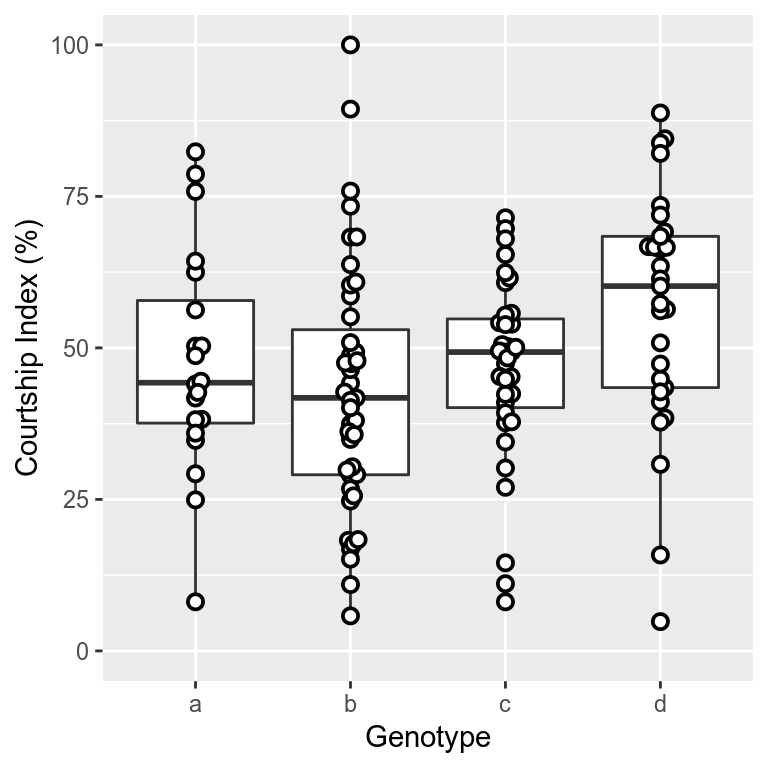

```r
indices <- courting_frames %>%
  filter(sex != "female") %>%
  group_by(uni_fly) %>%
  summarise(genotype = unique(genotype),
            CI = 100*sum(Courtship)/length(Frame),
            CIwF = 100*sum(CourtshipWithFacing)/length(Frame),
            approaching = 100*sum(Approaching)/length(Frame),
            contact = 100*sum(Contact)/length(Frame),
            circling = 100*sum(Encircling)/length(Frame),
            facing = 100*sum(Facing)/length(Frame),
            turning = 100*sum(Turning)/length(Frame),
            wing = 100*sum(WingGesture)/length(Frame)
            )

indices %>%
    ggplot(aes(x=genotype,y=CIwF)) +
    geom_boxplot(outlier.size = 0) +
    geom_beeswarm(shape = 21, colour = "black", fill = "white", size = 2, stroke = 1) +
    ylim(0,100) +
    ylab("Courtship Index (%)") +
    xlab("Genotype")
```

We can look at the individual courtship features to see what they look like. But as with CI, there doesn't look like there is any effect.

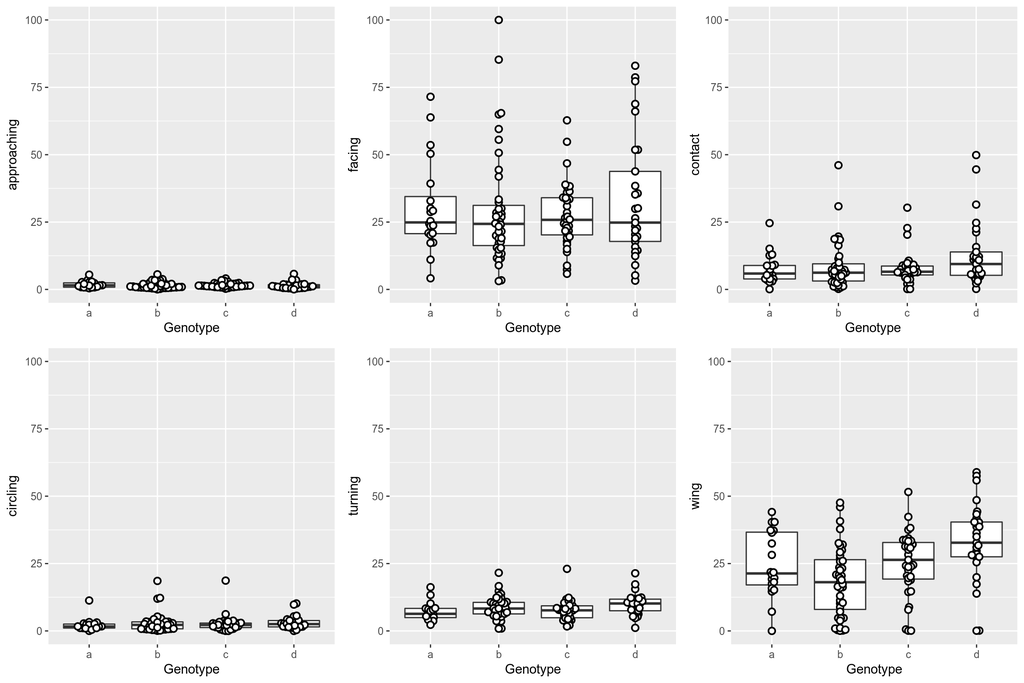

```r
p <- list()
courtship_features <- c("approaching","facing","contact","circling","turning","wing")
for (i in 1:length(courtship_features)) {
    p[[i]] <- indices %>%
        ggplot(aes_string(x="genotype",y=courtship_features[i])) +
        geom_boxplot(outlier.size = 0) +
        geom_beeswarm(shape = 21, colour = "black", fill = "white", size = 2, stroke = 1) +
        #geom_quasirandom(method = "smiley",shape = 21, colour = "black", fill = "white", size = 2, stroke = 1) +
        ylim(0,100) +
        ylab(as.name(courtship_features[i])) +
        xlab("Genotype")
}
plot_grid(plotlist = p,ncol = 3)
```

There also doesn't look like much of an effect on courtship initiation.

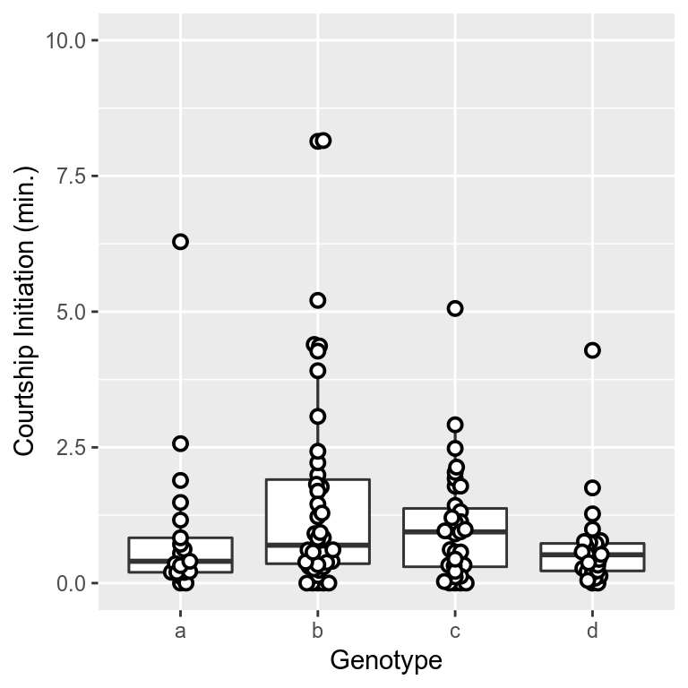

```r
ggplot(start_of_courtship_frames,aes(x=genotype,y=start_of_courtship/1500)) +
    geom_boxplot() +
    ylim(0,10) +
    geom_boxplot(outlier.size = 0) +
    geom_beeswarm(shape = 21, colour = "black", fill = "white", size = 2, stroke = 1) +
    ylab("Courtship Initiation (min.)") +
    xlab("Genotype")
```

There also doesn't look like much of an effect on cumulative copulation.

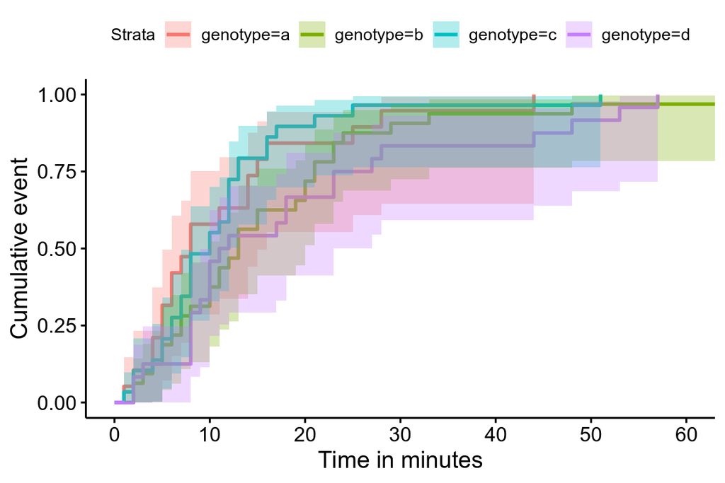

```r
df <- genotypes %>%
  mutate(status = if_else(is.na(copulation_time),0,1))
df$copulation_time <- round(as.numeric(df$copulation_time)/60)
fit <- survfit(Surv(copulation_time, status) ~ genotype, data = df)
ggsurv <- ggsurvplot(
            fit,
            data = df,
            risk.table = TRUE,
            pval = FALSE,
            conf.int = TRUE,
            xlim = c(0,60),
            xlab = "Time in minutes",
            break.time.by = 10,
            risk.table.y.text.col = T,
            risk.table.height = 0.25,
            risk.table.y.text = FALSE,
            ncensor.plot = TRUE,
            ncensor.plot.height = 0.25,
            fun = "event"
        )
ggsurv$plot
```

Looking at the position of the female while the male has it's wing extended, also looks quite similar. Which is in contrast to the "light" experiments. The males still generally keep the female close and in front, but there are more instances of the female being further away and behind. (*NB*: contralateral = left, ipsilateral = right, and the males postion is the centre)

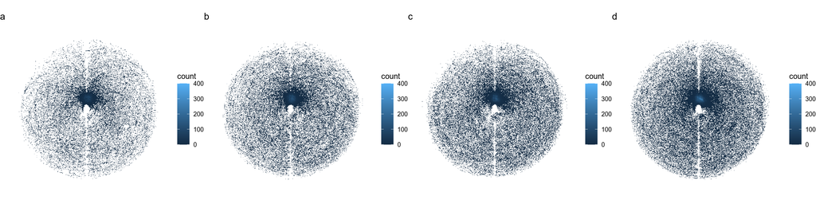

```r
p <- list()
male_genotypes <- c("a","b","c","d")
for (i in 1:length(male_genotypes)) {
    p[[i]] <- courting_frames %>%
                  filter(genotype==male_genotypes[i]) %>%
                  filter(max_wing_ang__rad > (35*pi/180)) %>%
                  ggplot(aes(x=ipsi_contra_rel_x,y=rel_y_other)) +
                  geom_bin2d(bins = c(400,400)) +
                  xlim(-20,20) +
                  ylim(-20,20) +
                  scale_fill_continuous(limits = c(0,400),na.value = "white") +
                  theme_void() +
                  coord_fixed() +
                  ggtitle(male_genotypes[i])
}
plot_grid(plotlist = p,ncol = 4)
```

Here we write a little function to look at the probability density plots of a given feature with a mean trend line and 95% confidence intervals.

```r
mean_pd <- function(input,feature,low=0,high,wing=TRUE,wing_ang=NULL, n=512){
  input <- input %>%
    filter(sex != "female") %>%
    select(uni_fly,Frame,genotype,feature, max_wing_ang__rad)

  output <- tibble()
  flies <- unique(input$uni_fly)
  for (fly in flies) {
    temp0 <- input %>%
      filter(uni_fly == fly) %>%
      do(
        if(wing)
          filter(., max_wing_ang__rad > wing_ang)
        else
          .
      )
    #message(dim(temp0)[1])
    if(dim(temp0)[1]<100) next

    feat <- temp0[[feature]][!is.na(temp0[[feature]])]
    den <- density(feat, from = low, to = high, n = n, na.rm = TRUE)
    temp1 <- tibble()
    temp1 <- tibble(uni_fly = rep(unique(temp0$uni_fly),length(den[["x"]])),
                    genotype = rep(unique(temp0$genotype),length(den[["x"]])),
                    x = den[["x"]],
                    pd = den[["y"]])
    output <- bind_rows(output,temp1)
  }
  return(output)
}
```

And there isn't anything strikingly different in the density of facing angle.

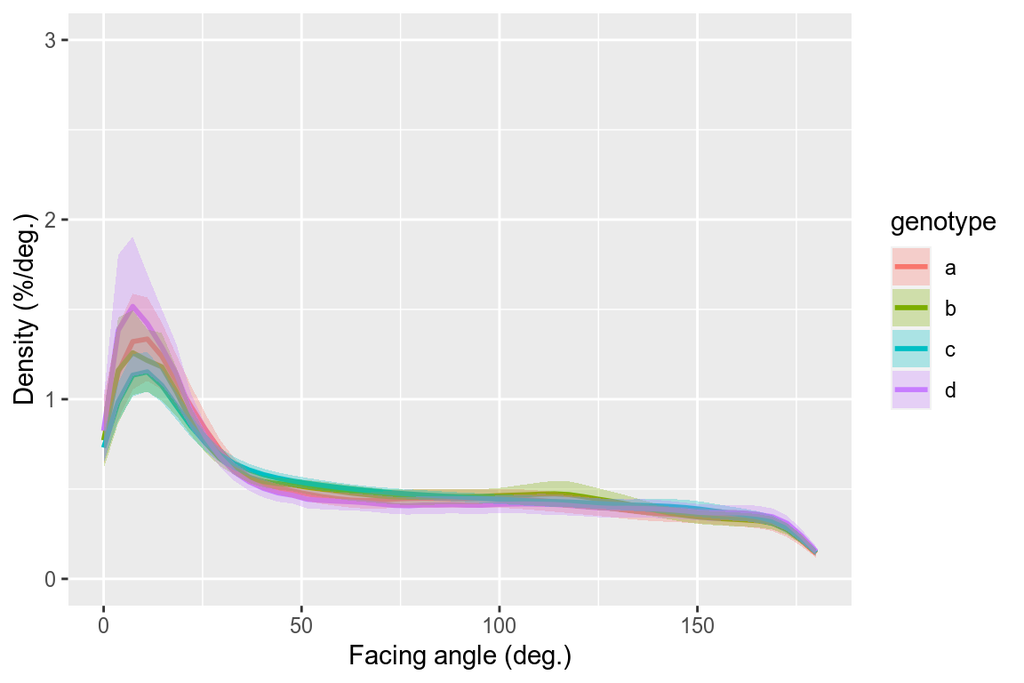

```r
facing_den <- mean_pd(input = courting_frames,feature = "facing_angle__rad",low = 0,high = pi, wing = FALSE, n=50)
facing_den %>%
  group_by(genotype,x) %>%
  summarise(y = mean(pd),
            err = qt(0.95,df=length(pd)-1)*sd(pd)/sqrt(length(pd))) %>%
  ggplot(aes(x=x*180/pi, y=100*y*pi/180)) +
  geom_line(aes(colour=genotype), size=1) +
  geom_ribbon(aes(ymin=if_else(y-err<0,0,(y-err)*100*pi/180), ymax=(y+err)*100*pi/180, fill=genotype), alpha = 0.3) +
  ylab("Density (%/deg.)") +
  xlab("Facing angle (deg.)") +
  ylim(0,3) +
  xlim(0,180)
```

Or distance.

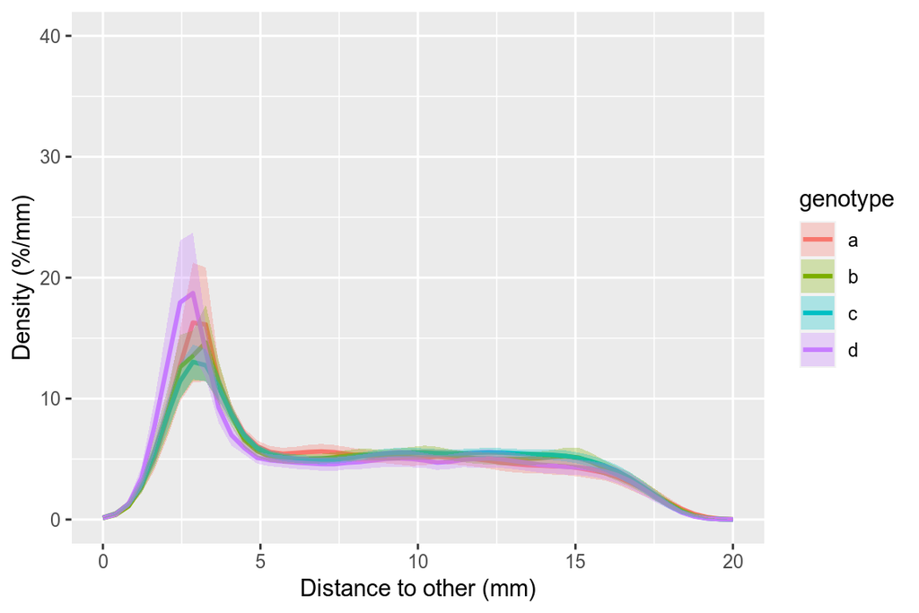

```r
distance_den <- mean_pd(input = courting_frames,feature = "dist_to_other__mm",low = 0,high = 20, wing = FALSE, n=50)
distance_den %>%
  group_by(genotype,x) %>%
  summarise(y = mean(pd),
            err = qt(0.95,df=length(pd)-1)*sd(pd)/sqrt(length(pd))) %>%
  ggplot(aes(x=x, y=y*100)) +
  geom_line(aes(colour=genotype), size=1) +
  geom_ribbon(aes(ymin=if_else(y-err<0,0,(y-err)*100), ymax=(y+err)*100, fill=genotype), alpha = 0.3) +
  ylab("Density (%/mm)") +
  xlab("Distance to other (mm)") +
  ylim(0,40) +
  xlim(0,20)
```

When we quantify the mean facing angle, mean distance to other, and minimum distance to other there is no difference between the flies. Bilateral wing index is trending up in the experimental, but we'll have to wait for the stats to see what's what.

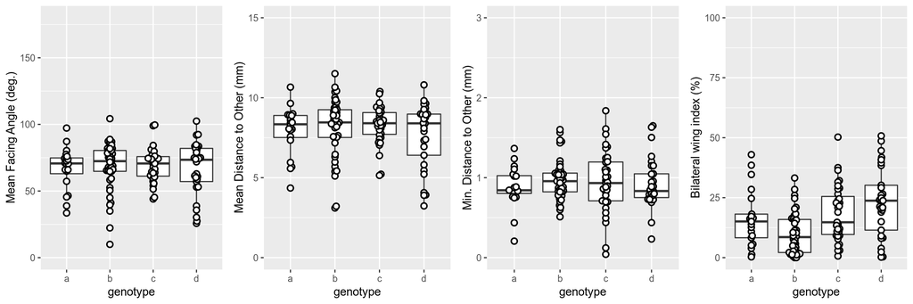

```r
p <- list()
p[[1]] <- courting_frames %>%
  filter(sex != "female") %>%
  group_by(uni_fly) %>%
  summarise(genotype = unique(genotype),
            facing = mean(facing_angle__rad)
  ) %>%
  ggplot(aes(x=genotype,y=facing*180/pi)) +
  geom_boxplot() +
  geom_beeswarm(shape = 21, colour = "black", fill = "white", size = 2, stroke = 1) +
  ylab("Mean Facing Angle (deg.)") +
  ylim(0,180)
p[[2]] <- courting_frames %>%
  filter(sex != "female") %>%
  group_by(uni_fly) %>%
  summarise(mean_dist = mean(dist_to_other__mm),
            genotype = unique(genotype)) %>%
  ggplot(aes(x=genotype, y=mean_dist)) +
  geom_boxplot() +
  geom_beeswarm(shape = 21, colour = "black", fill = "white", size = 2, stroke = 1) +
  ylab("Mean Distance to Other (mm)") +
  ylim(0,15)
p[[3]] <- courting_frames %>%
  filter(sex != "female") %>%
  group_by(uni_fly) %>%
  summarise(min_dist = min(dist_to_other__mm),
            genotype = unique(genotype)) %>%
  ggplot(aes(x=genotype, y=min_dist)) +
  geom_boxplot() +
  geom_beeswarm(shape = 21, colour = "black", fill = "white", size = 2, stroke = 1) +
  ylab("Min. Distance to Other (mm)") +
  ylim(0,3)
p[[4]] <- courting_frames %>%
  filter(sex != "female") %>%
  group_by(genotype) %>%
  group_by(uni_fly) %>%
  summarise(genotype = unique(genotype),
            both_wing_index = 100*sum(min_wing_ang__rad>(15*pi/180), na.rm = TRUE)/
              length(Frame)
  ) %>%
  ggplot(aes(x=genotype, y=both_wing_index)) +
  geom_boxplot() +
  geom_beeswarm(shape = 21, colour = "black", fill = "white", size = 2, stroke = 1) +
  ylab("Bilateral wing index (%)") +
  ylim(0,100)
plot_grid(plotlist = p,ncol = 4)
```

There is no apparent difference in wing choice index ether (not that there was one in light though). But all indices are lower than what we saw in the light. Again this is to be expected.

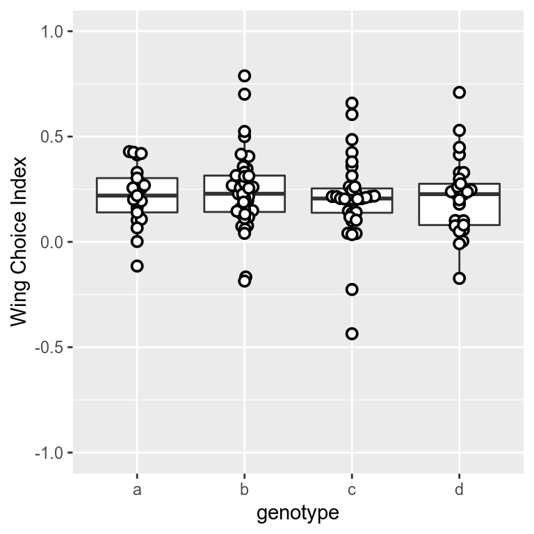

```r
courting_frames %>%
  filter(sex != "female") %>%
  group_by(uni_fly) %>%
  summarise(genotype = unique(genotype),
            wing_choice = (sum(abs(ipsi_wing_ang)>(35*pi/180),na.rm = T)-sum(abs(contra_wing_ang)>(35*pi/180),na.rm = T))/
              (sum(abs(ipsi_wing_ang)>(35*pi/180),na.rm = T)+sum(abs(contra_wing_ang)>(35*pi/180),na.rm = T))
  ) %>%
  ggplot(aes(x=genotype,y=wing_choice)) +
  geom_boxplot() +
  geom_beeswarm(shape = 21, colour = "black", fill = "white", size = 2, stroke = 1) +
  ylab("Wing Choice Index") +
  ylim(-1,1)
```

# **The Stats**

First lets compute a summary table of the features.

```r
court_summary <- courting_frames %>%
  filter(sex!="female") %>%
  group_by(uni_fly) %>%
  summarise(genotype = unique(genotype),
            initiation = min(Frame),
            CI = 100*sum(CourtshipWithFacing)/length(Frame),
            approaching = 100*sum(Approaching)/length(Frame),
            contact = 100*sum(Contact)/length(Frame),
            circling = 100*sum(Encircling)/length(Frame),
            facing = 100*sum(Facing)/length(Frame),
            turning = 100*sum(Turning)/length(Frame),
            wing = 100*sum(WingGesture)/length(Frame),
            time_behind = 100*sum(facing_angle__rad > (25*pi/180))/length(Frame),
            mean_facing_angle = mean(facing_angle__rad),
            mean_dist = mean(dist_to_other__mm),
            min_dist = min(dist_to_other__mm),
            bilateral_wing_index = 100*sum(min_wing_ang__rad>(15*pi/180), na.rm = TRUE)/length(Frame),
            uni_wing_index = 100*sum((max_wing_ang__rad>(35*pi/180) & min_wing_ang__rad < (15*pi/180)), na.rm = TRUE)/length(Frame),
            wing_choice = (sum(abs(ipsi_wing_ang)>(35*pi/180),na.rm = T)-sum(abs(contra_wing_ang)>(35*pi/180),na.rm = T))/
              (sum(abs(ipsi_wing_ang)>(35*pi/180),na.rm = T)+sum(abs(contra_wing_ang)>(35*pi/180),na.rm = T)),
            mean_min_wing = mean(min_wing_ang__rad)*180/pi
            )


temp <- courting_frames %>%
  filter(sex == "male")
uniq_fly <- unique(temp$uni_fly)
bi_wing_bouts <- tibble()
for (fly in uniq_fly) {
  temp2 <- temp %>%
    filter(uni_fly == fly) %>%
    mutate(bin_bilateral_wing = if_else(min_wing_ang__rad>(15*pi/180),1,0)
         )
  temp2$bin_bilateral_wing <- temp2$bin_bilateral_wing %>% replace_na(0)
  bilateral_wing_bouts <- rle(temp2[["bin_bilateral_wing"]])
  temp3 <- tibble(uni_fly = fly,
                  genotype = unique(temp2[["genotype"]]),
                  bilateral_wing_bout_rate = 60*25*sum(bilateral_wing_bouts$values==1)/length(temp2[["Frame"]]),
                  bilateral_wing_bout_length = mean(bilateral_wing_bouts$lengths[bilateral_wing_bouts$values==1])/25
                  )
  bi_wing_bouts <- bind_rows(bi_wing_bouts,temp3)
}
court_summary <- left_join(court_summary,bi_wing_bouts)
head(court_summary)
```

| uni_fly | genotype | initiation | CI | approaching | contact | circling | facing | turning | wing | time_behind | mean_facing_angle | mean_dist | min_dist | bilateral_wing_index | uni_wing_index | wing_choice | mean_min_wing | bilateral_wing_bout_rate | bilateral_wing_bout_length |
| --- | --- | --- | --- | --- | --- | --- | --- | --- | --- | --- | --- | --- | --- | --- | --- | --- | --- | --- | --- |
| annika-2020_10_08_courtship-2020_10_08_adn_dark_1 | d | 987 | 50.83091 | 0.4471272 | 4.828974 | 1.5947537 | 17.81057 | 6.229972 | 38.67650 | 76.61525 | 1.4082442 | 8.987234 | 0.8333604 | 41.798942 | 12.79529 | 0.09578844 | 13.832702 | 52.76101 | 0.4753390 |
| annika-2020_10_08_courtship-2020_10_08_adn_dark_10 | d | 408 | 66.71621 | 1.7747858 | 21.201259 | 3.6719706 | 51.83599 | 12.414758 | 29.71673 | 48.45253 | 0.9239104 | 5.453151 | 0.6912030 | 24.033922 | 21.26246 | 0.22411128 | 9.695028 | 39.08026 | 0.3689933 |
| annika-2020_10_08_courtship-2020_10_08_adn_dark_11 | a | 1 | 38.20889 | 1.7111111 | 5.315556 | 1.6888889 | 20.89778 | 8.328889 | 19.20444 | 75.24889 | 1.2992972 | 8.774064 | 0.8216351 | 16.191111 | 9.60000 | 0.16202673 | NaN | 41.53333 | 0.2339005 |
| annika-2020_10_08_courtship-2020_10_08_adn_dark_13 | a | 623 | 75.82046 | 1.8694579 | 15.106500 | 2.7744766 | 53.56523 | 9.022763 | 40.38303 | 47.34894 | 0.8111005 | 5.676555 | 0.8169767 | 24.686900 | 23.88244 | 0.32995799 | 10.035223 | 43.67401 | 0.3391523 |
| annika-2020_10_08_courtship-2020_10_08_adn_dark_15 | a | 3853 | 38.14886 | 1.5604891 | 3.898541 | 1.0725011 | 17.39060 | 4.649292 | 21.82540 | 77.12355 | 1.4020553 | 8.934657 | 0.2064993 | 8.295796 | 14.44659 | 0.10363153 | NaN | 21.23552 | 0.2343939 |
| annika-2020_10_08_courtship-2020_10_08_adn_dark_17 | a | 185 | 50.29127 | 2.3570532 | 3.405628 | 0.9544721 | 17.24771 | 6.591683 | 37.21097 | 78.13676 | 1.3523559 | 8.907969 | 0.8414755 | 34.661230 | 21.76465 | 0.10757071 | 11.855956 | 55.99122 | 0.3714286 |

And now we calculate a stats table and adjust for multiple comparisons/testing. Although not all the features were plotted above and calculating the stats for all the corresponding figures that we show for the in light experiments.

```r
features <- c("initiation","CI","mean_facing_angle","mean_dist","min_dist","bilateral_wing_index","bilateral_wing_bout_rate",
              "approaching","facing","contact","circling","turning","wing",
              "time_behind","uni_wing_index","bilateral_wing_bout_length","wing_choice")
figures <- c("4a","4b","4g","4h","4i","4j","4k",
             "s4a","s4b","s4c","s4d","s4e","s4f",
             "s4g","s4h","s4i","s4j")
all_pvals <- tibble()
anova_values <- tibble()
for (ii in 1:length(features)) {
  aov <- aov(court_summary[[features[ii]]]~court_summary[["genotype"]])
  temp_anova <- tibble(figure = figures[ii],
                       feature = features[ii],
                       df1 = summary(aov)[[1]][["Df"]][1],
                       df2 = summary(aov)[[1]][["Df"]][2],
                       fvalue = summary(aov)[[1]][["F value"]][1]
                    )
  anova_values <- bind_rows(anova_values,temp_anova)
  if (summary(aov)[[1]][["Pr(>F)"]][[1]]<0.05) {
    d_a <- t.test(court_summary[[features[ii]]][court_summary$genotype=="d"],court_summary[[features[ii]]][court_summary$genotype=="a"])
    d_b <- t.test(court_summary[[features[ii]]][court_summary$genotype=="d"],court_summary[[features[ii]]][court_summary$genotype=="b"])
    d_c <- t.test(court_summary[[features[ii]]][court_summary$genotype=="d"],court_summary[[features[ii]]][court_summary$genotype=="c"])
    temp_pvals <- tibble(figure = figures[ii],
                        feature = features[ii],
                        comparison = c("anova", "d-a t.test", "d-b t.test", "d-c t.test"),
                        pvals = c(summary(aov)[[1]][["Pr(>F)"]][[1]],d_a$p.value,d_b$p.value,d_c$p.value)
                    )
    all_pvals <- bind_rows(all_pvals,temp_pvals)
  } else {
      d_a <- NA
      d_b <- NA
      d_c <- NA
      temp_pvals <- tibble(figure = figures[ii],
                          feature = features[ii],
                          comparison = c("anova", "d-a t.test", "d-b t.test", "d-c t.test"),
                          pvals = c(summary(aov)[[1]][["Pr(>F)"]][[1]],NA,NA,NA)
                      )
      all_pvals <- bind_rows(all_pvals,temp_pvals)
  }
}

res0 <- survdiff(formula = Surv(copulation_time, status) ~ genotype, data = df)
res <- pairwise_survdiff(formula = Surv(copulation_time, status) ~ genotype, data = df, p.adjust.method = "none")
temp_pvals <- tibble(figure = "4c",
                     feature = "copulation",
                     comparison = c("chisq", "d-a log-rank test", "d-b log-rank test", "d-c log-rank test"),
                     pvals = c(1 - pchisq(res0$chisq, length(res0$n) - 1),res[["p.value"]][3,1],res[["p.value"]][3,2],res[["p.value"]][3,3])
                      )
all_pvals <- bind_rows(all_pvals,temp_pvals)

a_pd <- distance_den %>% filter(genotype == "a") %>% group_by(x) %>% summarise(y = mean(pd))
b_pd <- distance_den %>% filter(genotype == "b") %>% group_by(x) %>% summarise(y = mean(pd))
c_pd <- distance_den %>% filter(genotype == "c") %>% group_by(x) %>% summarise(y = mean(pd))
d_pd <- distance_den %>% filter(genotype == "d") %>% group_by(x) %>% summarise(y = mean(pd))
d_a <- ks.test(d_pd$y, a_pd$y, exact = TRUE)
d_b <- ks.test(d_pd$y, b_pd$y, exact = TRUE)
d_c <- ks.test(d_pd$y, c_pd$y, exact = TRUE)

temp_pvals <- tibble(figure = "4e",
                     feature = "dist_to_other",
                     comparison = c("d-a ks test", "d-b ks test", "d-c ks test"),
                     pvals = c(d_a$p.value,d_b$p.value,d_c$p.value)
                    )
all_pvals <- bind_rows(all_pvals,temp_pvals)

a_pd <- facing_den %>% filter(genotype == "a") %>% group_by(x) %>% summarise(y = mean(pd))
b_pd <- facing_den %>% filter(genotype == "b") %>% group_by(x) %>% summarise(y = mean(pd))
c_pd <- facing_den %>% filter(genotype == "c") %>% group_by(x) %>% summarise(y = mean(pd))
d_pd <- facing_den %>% filter(genotype == "d") %>% group_by(x) %>% summarise(y = mean(pd))
d_a <- ks.test(d_pd$y, a_pd$y, exact = TRUE)
d_b <- ks.test(d_pd$y, b_pd$y, exact = TRUE)
d_c <- ks.test(d_pd$y, c_pd$y, exact = TRUE)

temp_pvals <- tibble(figure = "4d",
                     feature = "facing_angle",
                     comparison = c("d-a ks test", "d-b ks test", "d-c ks test"),
                     pvals = c(d_a$p.value,d_b$p.value,d_c$p.value)
                    )
all_pvals <- bind_rows(all_pvals,temp_pvals)

all_pvals <- all_pvals %>%
  mutate(p_adj = p.adjust(pvals,"holm"),
         #sig = ifelse(p_adj<0.05,"y","n"),
         sig_level = ifelse(p_adj>0.1,"ns",
                            ifelse(p_adj>0.05,".",
                                    ifelse(p_adj>0.01,"*",
                                            ifelse(p_adj>0.001,"**",
                                                    ifelse(p_adj>0.001,"***","****")
                                                   )
                                           )
                                    )
                            )
         )
all_pvals <- all_pvals %>% arrange(figure)
all_pvals
```

| figure | feature | comparison | pvals | p_adj | sig_level |
| --- | --- | --- | --- | --- | --- |
| 4a | initiation | anova | 4.646662e-02 | 1.000000000 | ns |
| 4a | initiation | d-a t.test | 4.432258e-01 | 1.000000000 | ns |
| 4a | initiation | d-b t.test | 6.963346e-03 | 0.250680452 | ns |
| 4a | initiation | d-c t.test | 8.563947e-02 | 1.000000000 | ns |
| 4b | CI | anova | 2.770660e-02 | 0.720371498 | ns |
| 4b | CI | d-a t.test | 1.113941e-01 | 1.000000000 | ns |
| 4b | CI | d-b t.test | 6.453748e-03 | 0.238788671 | ns |
| 4b | CI | d-c t.test | 2.955589e-02 | 0.738897176 | ns |
| 4c | copulation | chisq | 7.642011e-02 | 1.000000000 | ns |
| 4c | copulation | d-a log-rank test | 5.450886e-02 | 1.000000000 | ns |

[output cut: 68 more lines]